# Public Joint Stock Company "Gazprom"

[figure not shown]

```python
Image(filename = '/home/vladimir/Downloads/Headquarter.jpg',width = 350) #Штаб квартира Газпрома в Москве
```

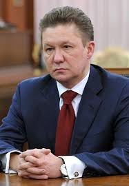

```python
Image('/home/vladimir/Downloads/miller.jpeg',width = 280) #Alexey Miller - CEO (заместитель председателя Совета директоров)
```

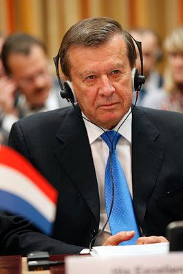

```python
Image('/home/vladimir/Downloads/zubkov.jpg') #Chairman (председатель Совета директоров)
```

ПАО «Газпром» - российская транснациональная энергетическая корпорация. В настоящее время государство контролирует более 50% акций. По версии S&P Global Platts, Газпром — крупнейшая энергетическая компания в мире.

Основные виды деятельности: геологоразведка, добыча, транспортировка, хранение , переработка и реализация газа, газового конденсата и нефти. Также производство и сбыт тепла и электроэнергии.

Доля располагаемых запасов газа составляет 17 % от мировых и 72 % от российских. На «Газпром» приходится 11 % мировой и 66 % российской добычи газа.

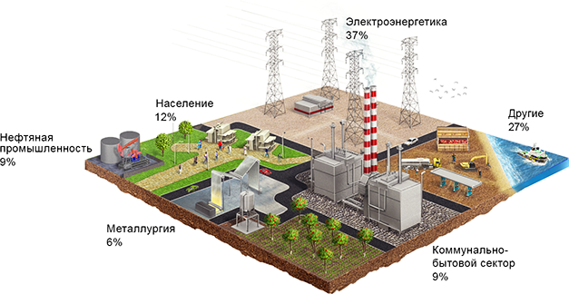

```python
Image(filename = '/home/vladimir/Downloads/Structure.png') #Структура потребления природного газа в России
```

# Стратегия

Стратегической целью является становление ПАО «Газпром» как лидера среди глобальных энергетических компаний посредством диверсификации рынков сбыта, обеспечения надежности поставок, роста эффективности деятельности, использования научно-технического потенциала.

Компании принадлежит крупнейшая в мире газотранспортная система, протяженность которой составляет 171,2 тыс. км. На внутреннем рынке «Газпром» реализует свыше половины продаваемого газа.

## Кроме того, компания поставляет газ в более чем 30 стран ближнего и дальнего зарубежья, основные из них:

- Узбекистан
- Таджикистан
- Вьетнам
- Бангладеш
- Германия
- Италия
- Франция
- Алжир
- Нигерия
- Бангладеш
- Боливия

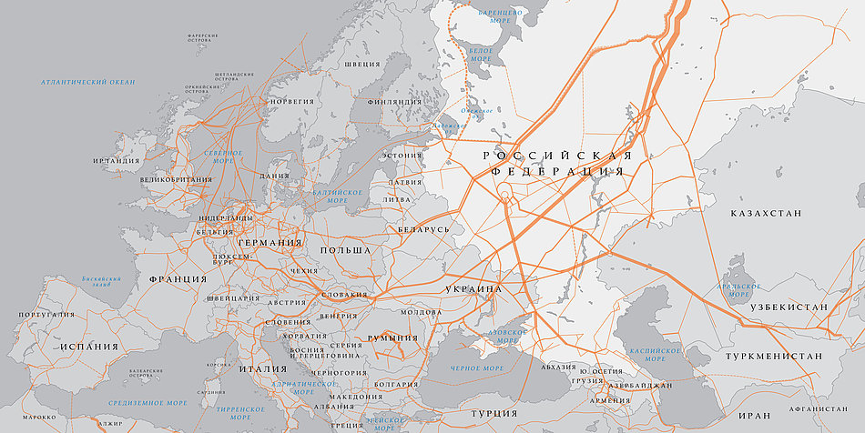

```python
Image(filename = '/home/vladimir/Downloads/GASnet.jpg') #Газотранспортная сеть
```

[figure not shown]

```python
Image('/home/vladimir/Domestic.png')
```

Благодаря географическому положению России, у компании есть возможность стать своеобразным энергетическим «мостом» между рынками Европы и Азии, поставляя собственный газ и оказывая услуги по транзиту газа другим производителям. Это предопределяет содержание стратегий компании в ее ключевых областях деятельности.

«Газпром» является единственным в России производителем и экспортером сжиженного природного газа (СПГ). Компания успешно развивает торговлю СПГ в рамках действующего проекта «Сахалин-2», а также реализует новые проекты, которые позволят «Газпрому» значительно усилить свои позиции на быстрорастущем мировом рынке СПГ.

# Проекты:

```
  Сахалин-2 — проект, в рамках которого был построен и в 2009 году начал работать первый в России завод по производству СПГ мощностью 9,6 млн тонн в год.

  Владивосток-СПГ — проект предполагает строительство в районе Владивостока завода по производству сжиженного природного газа.

  Балтийский-СПГ — в рамках проекта предполагается построить в Ленинградской области завод по производству СПГ мощностью до 10 млн тонн в год.

  Регазификационный терминал СПГ в Калининградской области — в рамках проекта предполагается построить терминал мощностью не менее 9 млн куб. м газа в сутки.
```

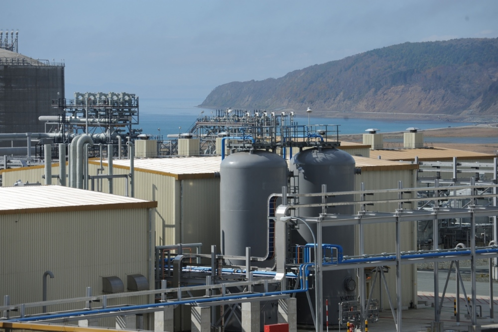

```python
Image('/home/vladimir/Pictures/GAS.jpg') #завод по производству СПГ на Сахалине
```

```python
disp.Video('/home/vladimir/Videos/LNG.mp4') # Технология транспортировки СПГ
```

[video not shown]

# История развития

Открытие больших месторождений газа в Сибири, на Урале и в Поволжье в 1960-е 1970-е 1980-е и 1990-е годы сделало СССР одной из крупнейших газодобывающих стран. В 1965 году образовано Министерство газовой промышленности СССР, которое ведало поиском газовых месторождений, добычей газа, его доставкой и продажей. В августе 1990 года постановлением Совета Министров СССР Министерство газовой промышленности СССР преобразовано в государственный газодобывающий концерн «Газпром» (в 1993 году ставшее РАО «Газпром»). Главой «Газпрома» стал Виктор Черномырдин.

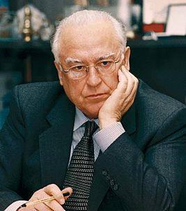

```python
Image(filename = '/home/vladimir/Downloads/header.jpg') #Черномырдин Виктор Степанович
```

В 1991 году в результате распада СССР «Газпром» потерял часть своего имущества на территории бывших советских республик — треть трубопроводов и четверть мощности компрессорных станций.

### Основные даты

2005: В 2005 году «Газпром» осуществил первые поставки сжиженного природного газа в США.

2009: На Сахалине запущен первый завод по производству сжиженного природного газа.(СПГ)

2012: «Газпром» начал работу по выводу рынка газомоторного топлива в России на принципиально новый уровень развития. В России появился новый крупный центр газодобычи — полуостров Ямал. Запущены Бованенковское месторождение и система магистральных газопроводов «Бованенково — Ухта».

2013: Начата добыча нефти на Приразломном месторождении. Это первый в истории России проект по освоению ресурсов шельфа Арктики. «Газпром» первым в России начал использовать подводные технологии добычи газа — на Киринском месторождении на шельфе Сахалина.

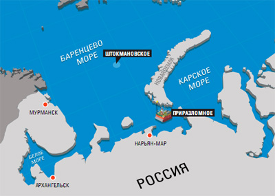

```python
Image('/home/vladimir/Downloads/Приразломное.jpg')
```

1 сентября 2014: Дан старт строительству газопровода «Сила Сибири».

2 декабря: «Газпром» и Botas Petroleum Pipeline Corporation подписали меморандум о взаимопонимании по строительству морского газопровода через Черное море в направлении Турции (проект «Турецкий поток»).

21 июля: «Газпром» стал публичным акционерным обществом.

14 октября: Началось строительство Амурского газоперерабатывающего завода, крупнейшего в России и одного из самых больших в мире предприятий по переработке природного газа.

2016: 25 мая: Началась круглогодичная отгрузка нефти Новопортовского месторождения через арктический нефтеналивной терминал «Ворота Арктики».

## Структура экспорта газа в Европу

[Поставки газа в Европу](http://www.gazprom.ru/about/marketing/europe/)

# Индек трансациональности - степень вовлечённости компании в производство за рубежом.

$IT = \frac{(Аз/Ао + Пз/По + Шз/Шо)}{3}*100\% $

где :

- Аз — зарубежные активы;
- Ао — общие активы
- Пз — объем продаж товаров и услуг зарубежными филиалами;
- По — общий объем продаж товаров и услуг;
- Шз — зарубежный штат;
- Шо — общий штат работников компании.

[Cyberleninka](https://cyberleninka.ru/article/v/k-voprosu-o-transnatsionalizatsii-rossiyskih-kompaniy-neftegazovogo-sektora) - источник ниже приведенной информации

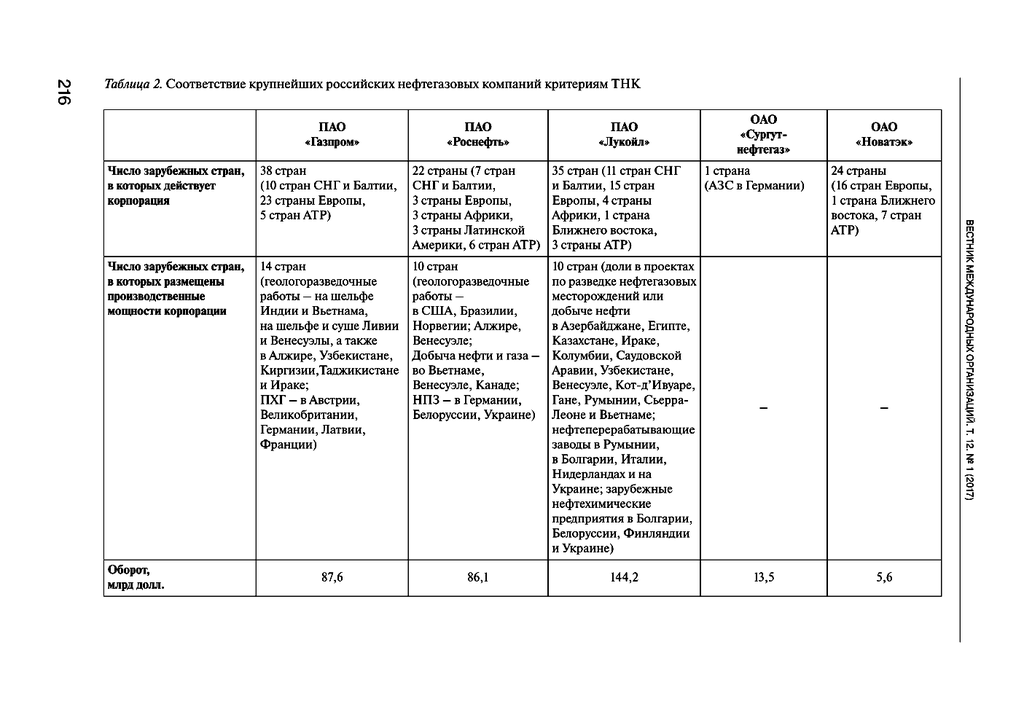

```python
Image('/home/vladimir/Downloads/Branches.png')
```

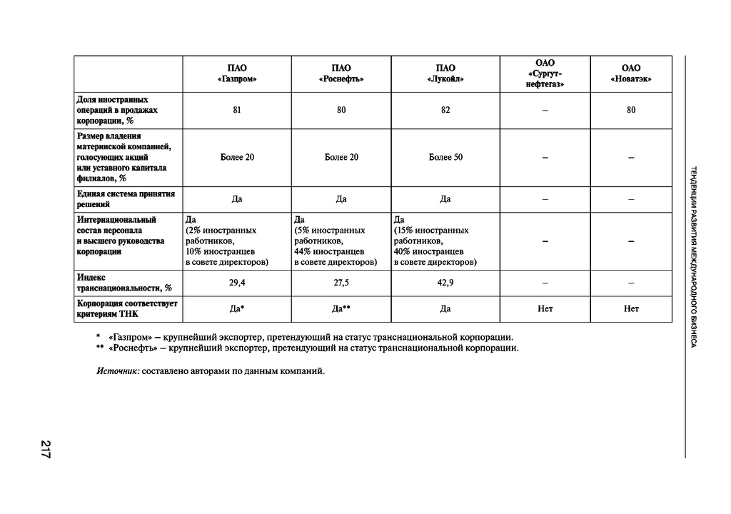

```python
Image('/home/vladimir/Downloads/Branches1.png')
```

### Филиалы,дочерние и ассоциированные компании

```python
data.head(5)
```

|  | Ассоциированные компании | Дочерние компании | Филиалы |
| --- | --- | --- | --- |
| 0 | - | Белгазпромбанк (ОАО) | Авиапредприятие «Газпром авиа» (ООО) |
| 1 | - | Брестгазоаппарат (СП ОАО) | Газпромтранс (ООО) |
| 2 | - | - | Газпром Армения (ЗАО) |
| 3 | - | ВНИПИгаздобыча (ОАО) | Газпром ВНИИГАЗ (ООО) |
| 4 | - | - | Газпром газнадзор (ООО) |

```python
data[5:10]
```

|  | Ассоциированные компании | Дочерние компании | Филиалы |
| --- | --- | --- | --- |
| 5 | ВНИПИгаздобыча (ОАО) | Востокгазпром (ОАО) | Газпром газобезопасность (ООО) |
| 6 | - | Газпромвьет (ООО) | Газпром геологоразведка (ООО) |
| 7 | Востокгазпром (ОАО) | - | Газпром георесурс (ООО) |
| 8 | - | Газпромтрубинвест (ОАО) | Газпром геотехнологии (ООО) |
| 9 | Газпромтрубинвест (ОАО) | Газпром бытовые системы (АО) | Газпром добыча Иркутск (ООО) |

```python
data[10:15]
```

|  | Ассоциированные компании | Дочерние компании | Филиалы |
| --- | --- | --- | --- |
| 10 | Газпром бытовые системы (АО) | Газпром космические системы (АО) | Газпром добыча Краснодар (ООО) |
| 11 | - | - | Газпром добыча Кузнецк (ООО) |
| 12 | Газпром космические системы (АО) | - | Газпром добыча Надым (ООО) |
| 13 | - | Газпром нефть (ПАО) | Газпром добыча Ноябрьск (ООО) |
| 14 | Газпром нефть (ПАО) | - | Газпром добыча Уренгой (ООО) |

```python
data[15:20]
```

|  | Ассоциированные компании | Дочерние компании | Филиалы |
| --- | --- | --- | --- |
| 15 | - | Газпром промгаз (АО) | Газпром добыча шельф Южно-Сахалинск (ООО) |
| 16 | Газпром подземремонт Оренбург (ООО) | Газпром спецгазавтотранс (ПАО) | Газпром добыча Ямбург (ООО) |
| 17 | - | Гипрогазцентр (АО) | Газпром инвестпроект (ООО) |
| 18 | Газпром подземремонт Уренгой (ООО) | Гипроспецгаз (АО) | Газпром инвестхолдинг (ООО) |
| 19 | - | Дальтрансгаз (ОАО) | Газпром инвест (ООО) |

```python
data[20:25]
```

|  | Ассоциированные компании | Дочерние компании | Филиалы |
| --- | --- | --- | --- |
| 20 | Газпром промгаз (АО) | - | Газпром информ (ООО) |
| 21 | Красноярскгазпром (ПАО) | - | Газпром капитал (ООО) |
| 22 | Красноярскгазпром (ПАО) | - | Газпром комплектация (ООО) |
| 23 | Кузбассгазификация (ОАО) | Красноярскгазпром (ПАО) | Газпром Кыргызстан (ОсОО) |
| 24 | Лазурная (ООО) | Кузбассгазификация (ОАО) | Газпром межрегионгаз (ООО) |

```python
data[25:30]
```

|  | Ассоциированные компании | Дочерние компании | Филиалы |
| --- | --- | --- | --- |
| 25 | Лазурная (ООО) | Лазурная (ООО) | Газпром охрана ЧОП (ООО) |
| 26 | Лидер (ЗАО) | - | Газпром переработка (ООО) |
| 27 | - | Лидер (ЗАО) | Газпром проектирование (ООО) |
| 28 | - | СевКавНИПИгаз (ОАО) | Газпром ПХГ (ООО) |
| 29 | - | СОГАЗ (АО) | Газпром связь (ООО) / |

```python
data[30:35]
```

|  | Ассоциированные компании | Дочерние компании | Филиалы |
| --- | --- | --- | --- |
| 30 | - | Центргаз (АО) | Газпром социнвест (ООО) |
| 31 | Росшельф (ЗАО) | ЦКБН | Газпром СПГ Владивосток (ООО) |
| 32 | Севернефтегазпром (ОАО) | Nord Stream AG | Газпром СПГ Санкт-Петербург (ООО) |
| 33 | Севернефтегазпром (ОАО) | Shtokman Development AG | Газпром телеком (ООО) |
| 34 | - | - | Газпром трансгаз Беларусь (ОАО) |

```python
data[35:40]
```

|  | Ассоциированные компании | Дочерние компании | Филиалы |
| --- | --- | --- | --- |
| 35 | СОГАЗ (АО) | - | Газпром трансгаз Волгоград (ООО) |
| 36 | - | - | Газпром трансгаз Екатеринбург (ООО) |
| 37 | Центргаз (АО) | - | Газпром трансгаз Казань (ООО) |
| 38 | Gazprom EP International | - | Газпром трансгаз Краснодар (ООО) |
| 39 | - | - | Газпром трансгаз Махачкала (ООО) |

```python
data[40:45]
```

|  | Ассоциированные компании | Дочерние компании | Филиалы |
| --- | --- | --- | --- |
| 40 | - | - | Газпром трансгаз Москва (ООО) |
| 41 | Банк ГПБ (АО) | - | Газпром трансгаз Нижний Новгород (ООО) |
| 42 | - | - | Газпром трансгаз Самара (ООО) |
| 43 | - | - | Газпром трансгаз Санкт-Петербург (ООО) spb- |
| 44 | - | - | Газпром трансгаз Саратов (ООО) |

```python
data[45:50]
```

|  | Ассоциированные компании | Дочерние компании | Филиалы |
| --- | --- | --- | --- |
| 45 | - | - | Газпром трансгаз Ставрополь (ООО) |
| 46 | - | - | Газпром трансгаз Сургут (ООО) |
| 47 | - | - | Газпром трансгаз Томск (ООО) |
| 48 | - | - | Газпром трансгаз Уфа (ООО) |
| 49 | - | - | Газпром трансгаз Ухта (ООО) |

```python
data[50:55]
```

|  | Ассоциированные компании | Дочерние компании | Филиалы |
| --- | --- | --- | --- |
| 50 | - | - | Газпром трансгаз Чайковский (ООО) |
| 51 | - | - | Газпром трансгаз Югорск (ООО) |
| 52 | - | - | Газпром флот (ООО) |
| 53 | - | - | Газпром центрремонт (ООО) |
| 54 | - | - | Газпром экспорт (ООО) |

```python
data[55:60]
```

|  | Ассоциированные компании | Дочерние компании | Филиалы |
| --- | --- | --- | --- |
| 55 | - | - | Газпром экспо (ООО) |
| 56 | - | - | Газпром энергохолдинг (ООО) |
| 57 | - | - | Газпром энерго (ООО) |
| 58 | - | - | Ойл (ООО) |
| 59 | - | - | Кировгипрогаз (ОАО) |

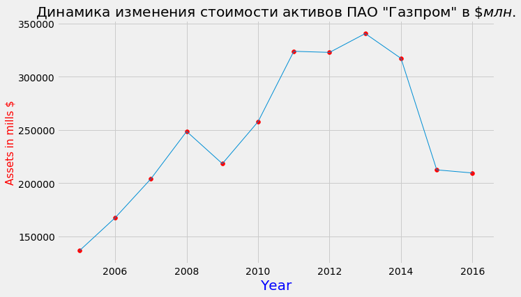

```python
plt.show()
```

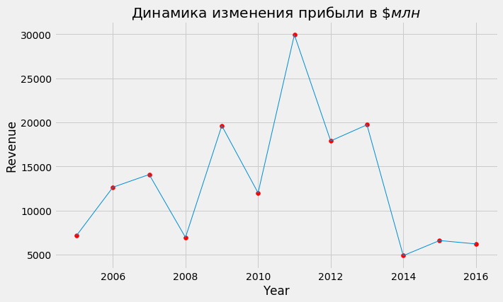

```python
plt.show(ax2)
```

```python
data #табличная форма
```

|  | USD/RUB | Активы в млн.руб. | Активы в млн. долл. | Прибыль в млн.руб. | Прибыль в млн.долл. |
| --- | --- | --- | --- | --- | --- |
| 2005 | 28.30 | 3865890 | 136603.89 | 203438.682 | 7188.646007 |
| 2006 | 27.17 | 4553244 | 167583.51 | 343680.067 | 12649.247957 |
| 2007 | 25.58 | 5221417 | 204121.07 | 360449.550 | 14091.069195 |
| 2008 | 24.86 | 6181534 | 248653.82 | 173021.630 | 6959.840306 |
| 2009 | 31.83 | 6950737 | 218370.63 | 624613.273 | 19623.414169 |
| 2010 | 30.36 | 7827957 | 257837.85 | 364577.256 | 12008.473518 |
| 2011 | 29.39 | 9520654 | 323941.95 | 879601.664 | 29928.603743 |
| 2012 | 31.08 | 10035651 | 322897.39 | 556340.354 | 17900.268790 |
| 2013 | 31.85 | 10848419 | 340609.70 | 628311.221 | 19727.196892 |
| 2014 | 38.61 | 12249735 | 317268.45 | 188980.016 | 4894.587309 |
| 2015 | 61.07 | 12981247 | 212563.40 | 403522.806 | 6607.545538 |
| 2016 | 66.08 | 13852945 | 209639.00 | 411424.597 | 6226.159156 |

# Меняющиеся рынки

В середине февраля 2013 года акции Газпрома опустились на уровень 3-летнего минимума: прибыль за 2012 год упала на 15% от прогнозируемого уровня из-за снижения объемов продаж на европейских рынках. Этот факт отражает ключевое изменение его позиций на рынке. Экспорт в Европу был ядром доходов Газпрома, но, после подорвавшего европейский спрос глобального экономического спада 2008 года, вторым ударом по этой болевой точке стал североамериканский сланцевый бум, косвенно приведший к переформатированию рынка.

Благодаря техническому прогрессу, буровики США и Канады приступили к добыче до совсем недавнего времени недоступных углеводородов из сланцевых пород. Соединенные Штаты в настоящее время стали самодостаточной страной в плане газа и планируют экспорт сжиженного природного газа (СПГ) в Европу по ценам, значительно более низким, чем рыночные, выгодные Газпрому, который нацелен на долгосрочные контракты с высокими ценами на нефть.

Западные поставщики, такие, как норвежская Statoil, также давно практикуют долгосрочные индексированные цены на нефтепродукты, но норвежская компания реагирует на динамику рынка и привлекает клиентов, предлагая скидки при ценообразовании, тогда как Газпром этому сопротивляется, особенно в Восточной Европе.

Из-за этих факторов — падения спроса и роста конкуренции — Газпром потерял 33% своего европейского экспорта по сравнению с пиком, который был в 2008 году

# Спасибо за внимание